# Posts

How-to articles to solve scientific problems

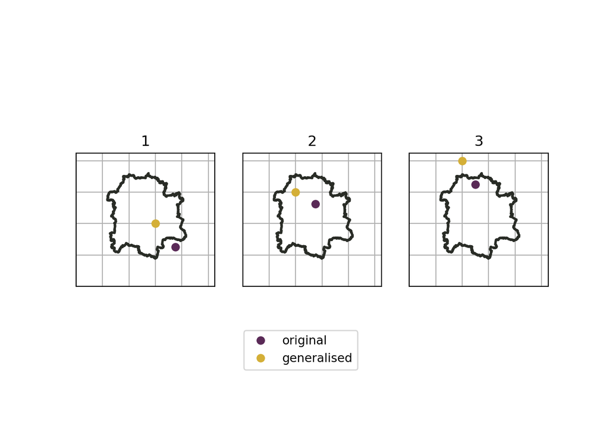

### Add a buffer to a shapefile and account for obfuscated species locations

Knowing what species have been observed in a local area is a regular task for ecosystem management. Here we show how to add a buffer to a shapefile using {shapely} and {geopandas}. We then demonstrate how data that have been obfuscated (i.e. their location has been made less precise) may affect the buffer size required to more confidently capture threatened species in the area using {galah-python} and {matplotlib}.

Aug 26, 2025

24 min

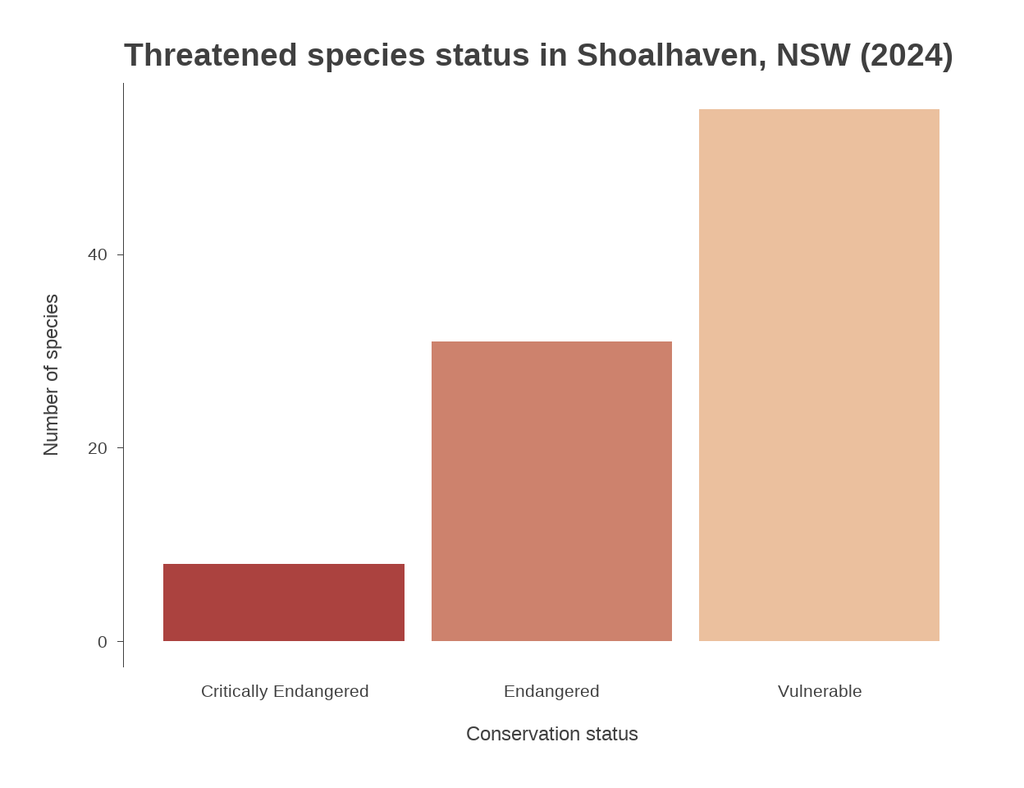

### Download a species list and cross-reference with conservation status lists in R

Knowing what species have been observed in a local area is a regular task for ecosystem management. Here we show how to make a species list and how to cross-reference this list with threatened and sensitive species lists. We show how to do this task using 2 methods, with {galah} and using an external shapefile and species list. We then show how to visualise this information as a bar chart and a waffle chart using {ggplot2}.

Jul 13, 2025

Dax Kellie, Amanda Buyan

20 min

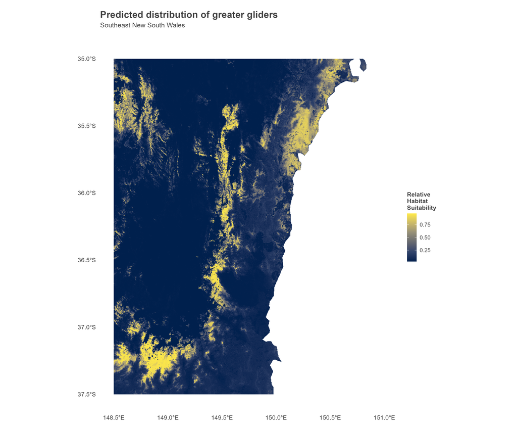

### Modelling the impact of fire on the Southern Greater Glider

Major fire events impact flora and fauna, particularly in areas where fire can dramatically reshape the livable habitat area. Here we investigate how greater gliders, a tree-dwelling marsupial species, were impacted by the 2019-2020 bushfires using {tidymodels} and {tidysdm}.

Apr 2, 2025

Jarod Wright, Dax Kellie

59 min

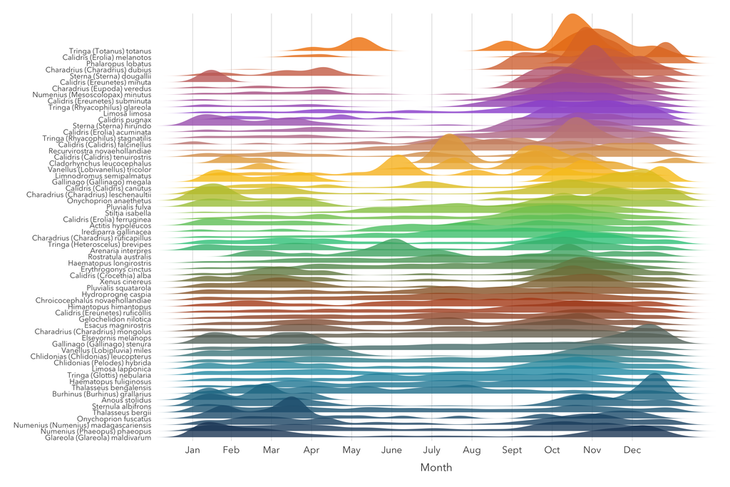

### Show seasonal species trends using a ridgeline plot

Displaying ecological trends of many species or groups at once can sometimes appear messy or crowded. In this post we show how ridgeline plots are a useful way to show trends in seasonality by displaying observations of migratory bird species over the year using {ggridges}.

May 10, 2024

Olivia Torresan, Dax Kellie

11 min

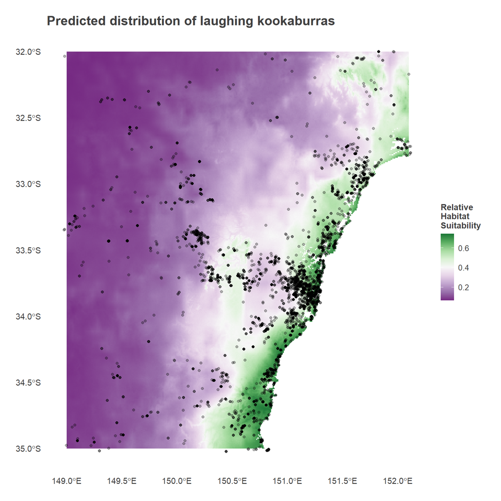

### An introduction to species distribution modelling using {tidysdm} & {tidymodels}

Species distribution modelling is a common task for ecologists in R. Here we show the fundamental steps to build, assess and use models to predict species distributions using {tidymodels} & {tidysdm}, modern packages that use tidy syntax to run and plot geospatial models.

Apr 30, 2024

Dax Kellie, Shandiya Balasubramaniam

32 min

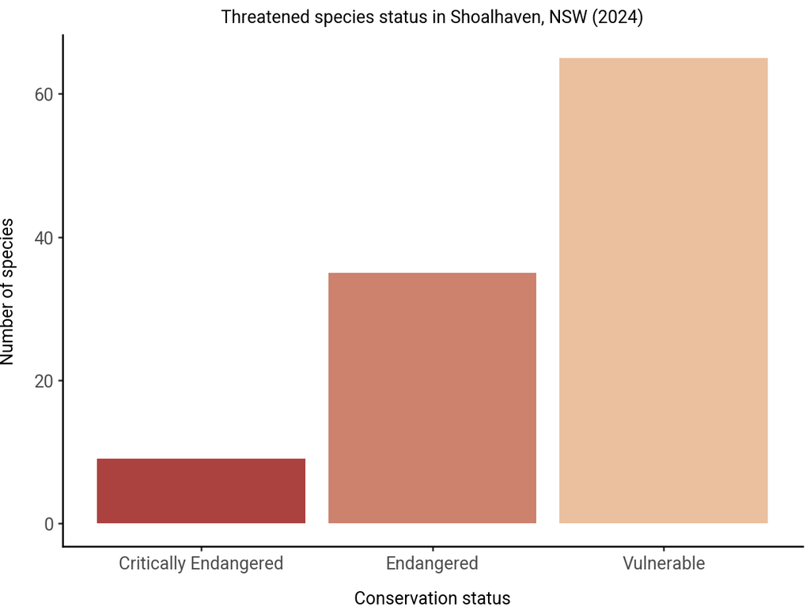

### Download a species list and cross-reference with conservation status lists in Python

Knowing what species have been observed in a local area is a regular task for ecosystem management. Here we show how to make a species list with {galah-python} and how to cross-reference this list with threatened and sensitive species lists. We then show how to visualise this information as a waffle chart using {pywaffle} & {matplotlib}.

Feb 12, 2024

Dax Kellie, Amanda Buyan

19 min

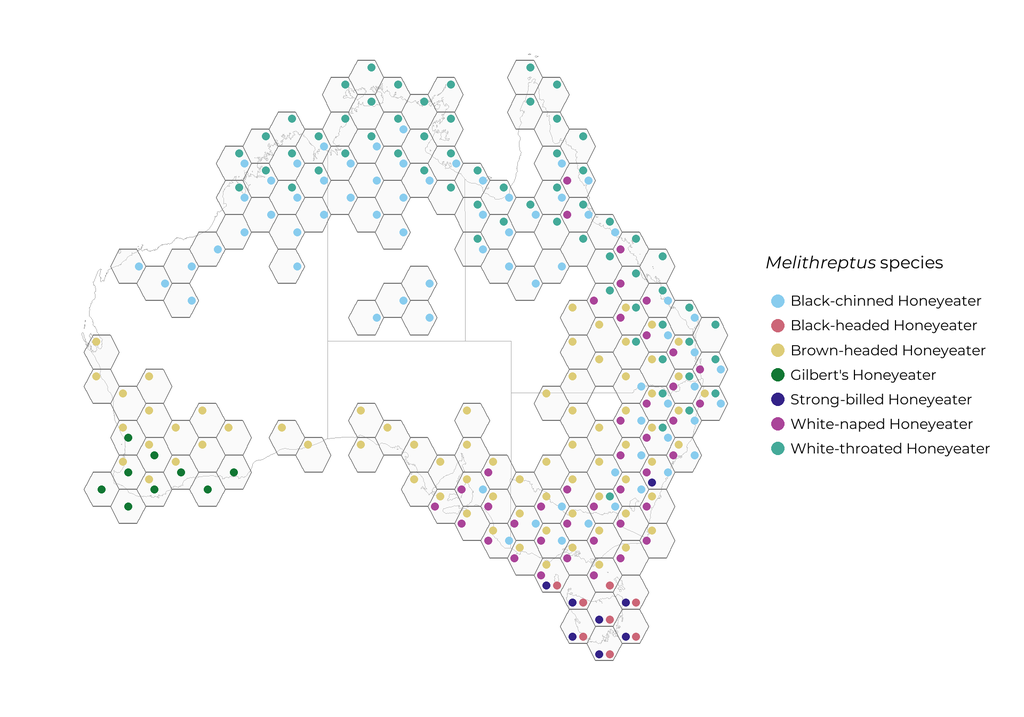

### Combining multiple species distributions on one map with hexagons and points

Visualising multiple species distributions in a single figure can be difficult if there are areas where ranges overlap. In this post we introduce a way to show several species distributions in an area at once using a novel twist on the commonly used hexbin map.

Jan 25, 2024

Callum Waite, Shandiya Balasubramaniam

20 min

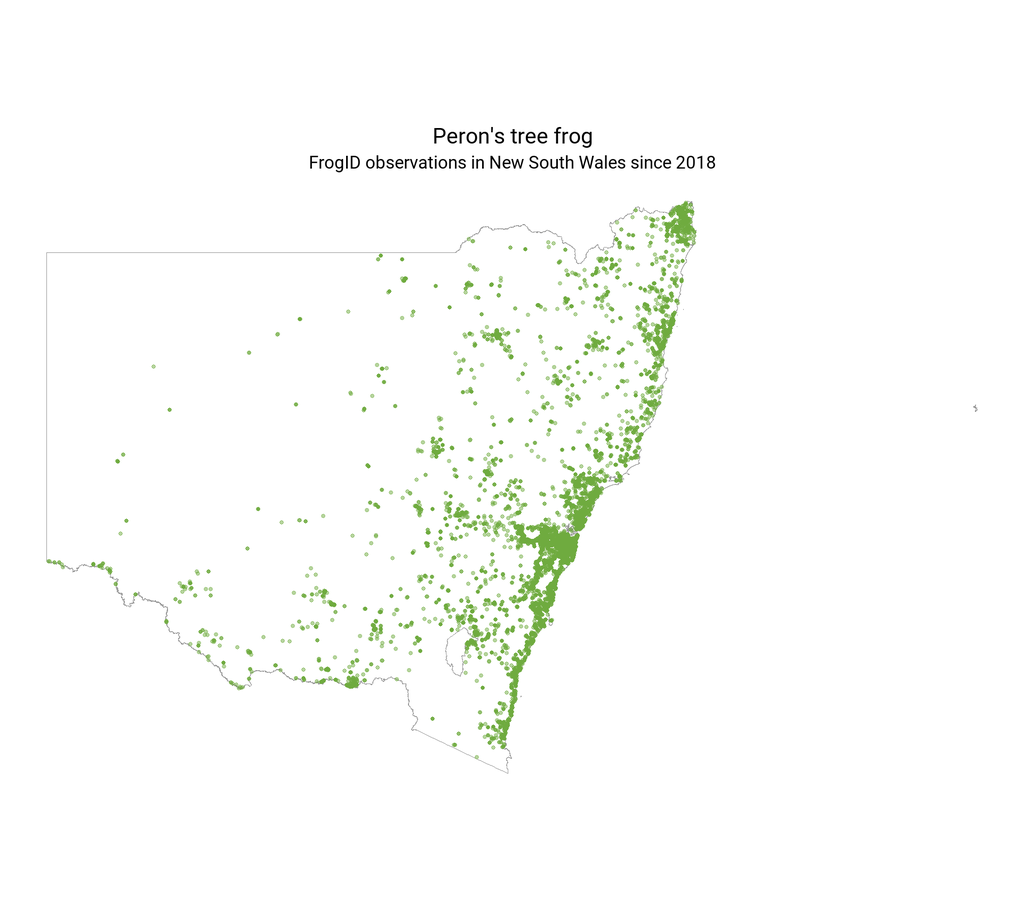

### Beginner’s guide: Make a quick map of species observations in Python and R

The ability to make a map quickly is an essential skill in ecology and conservation. This post shows how to make a quick, simple map of Peron’s tree frog occurrences & set a custom font using either Python or R.

Dec 18, 2023

Amanda Buyan, Dax Kellie

19 min

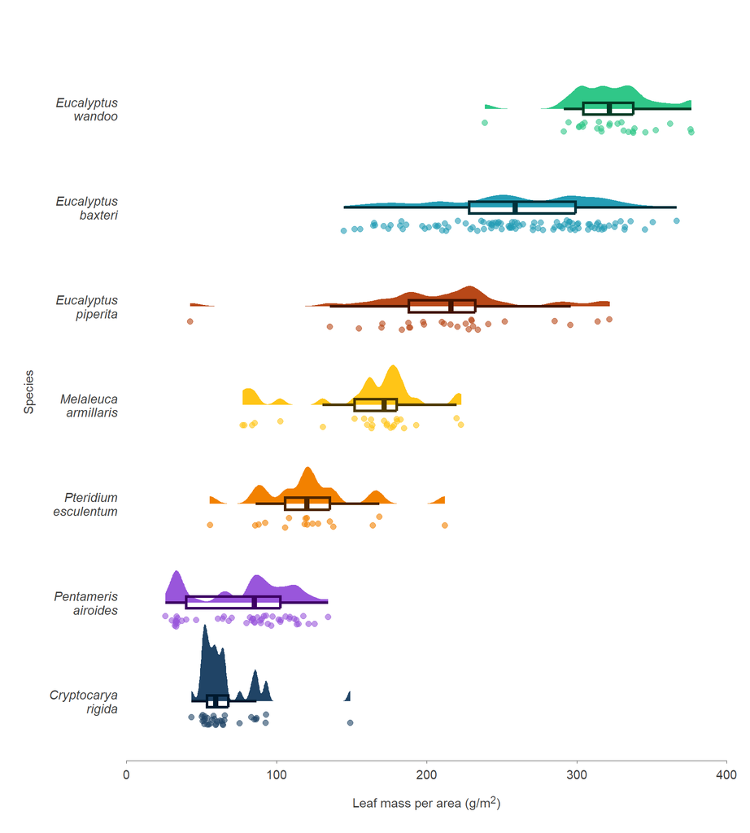

### Alternatives to box plots: Using beeswarm and raincloud plots to summarise ecological data

Box plots are a common way to summarise data in ecology and biology research, but box plots have their weaknesses. Here we’ll show how easy it can be to make beeswarm and raincloud plots—two alternatives with greater data transparency—using plant trait data from {austraits}.

Aug 28, 2023

Dax Kellie, Shandiya Balasubramaniam

26 min

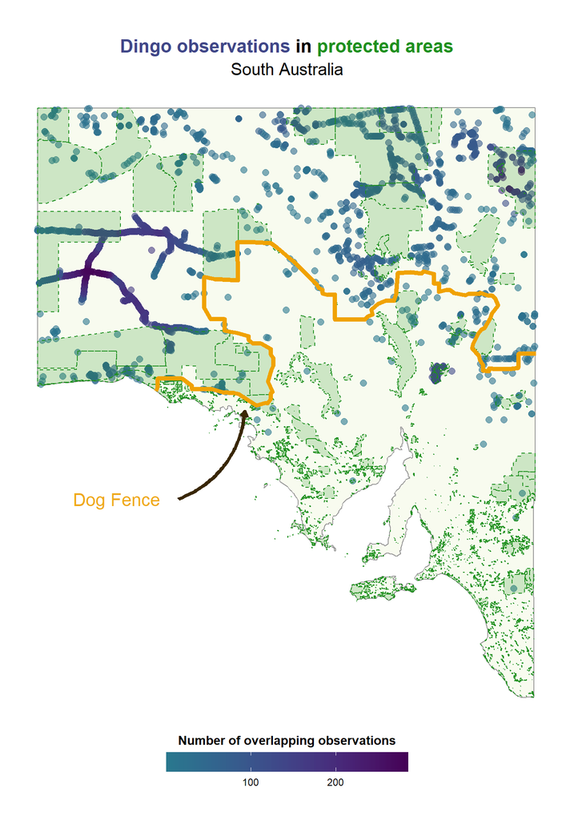

### An exploration of dingo observations in the ALA

Dingoes are the subject of ongoing debate about whether they should be considered a protected species or a pest species. Here we explore dingo observations in the ALA to understand how differing attitudes affect dingo data, plotting spatial and temporal trends using {ggplot2}.

May 16, 2023

Amos Smith, Dax Kellie

23 min

[figure not shown]

### Plotting invasive species distributions with alpha shapes and choropleth maps in Python

Invasive and introduced species can expand quickly into new habitats, altering ecosystems. In this post we use Python’s {galah}, {alphashape} and {GeoPandas} packages to visualise the growing distribution of *Rhinella marina* (cane toads) and the expanding range of *Pittisporum undulatum* in Australia.

Apr 28, 2023

Caitlin Ramsay, Amanda Buyan, Dax Kellie

13 min

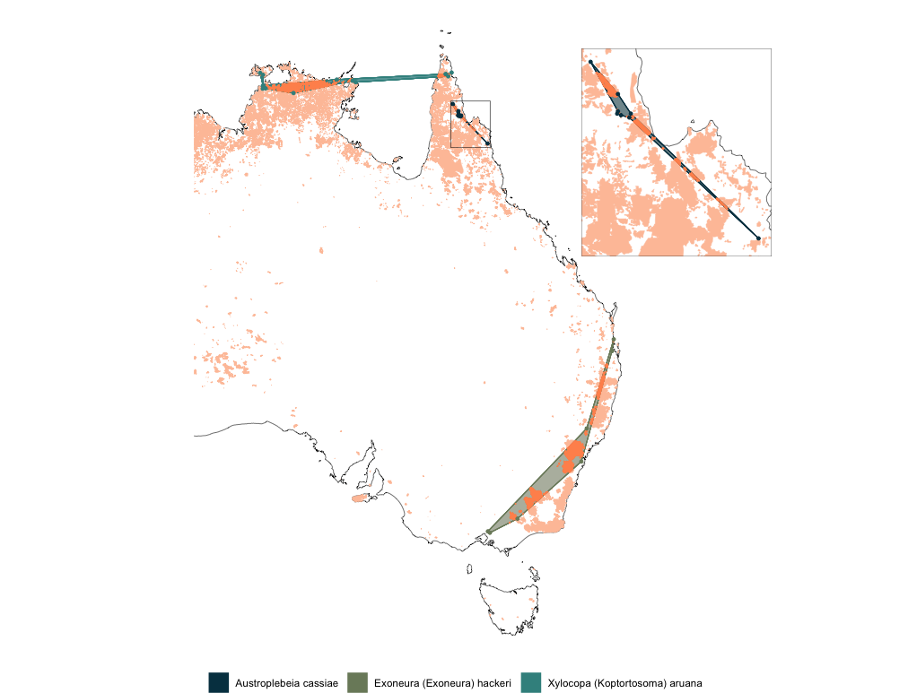

### Quantifying species range and overlap with fire-burned areas using concave hulls

Calculating range overlap is an efficient way to estimate the impact of natural disasters on biodiversity. Here we’ll use curated datasets to compute concave hulls to visualise the spatial distribution of *Apidae* (Bees) and *Daviesia* (Bitterpeas) and their overlap with burned areas of the Black Summer fires of 2019-2020.

Apr 11, 2023

Fonti Kar, Margot Schneider

25 min

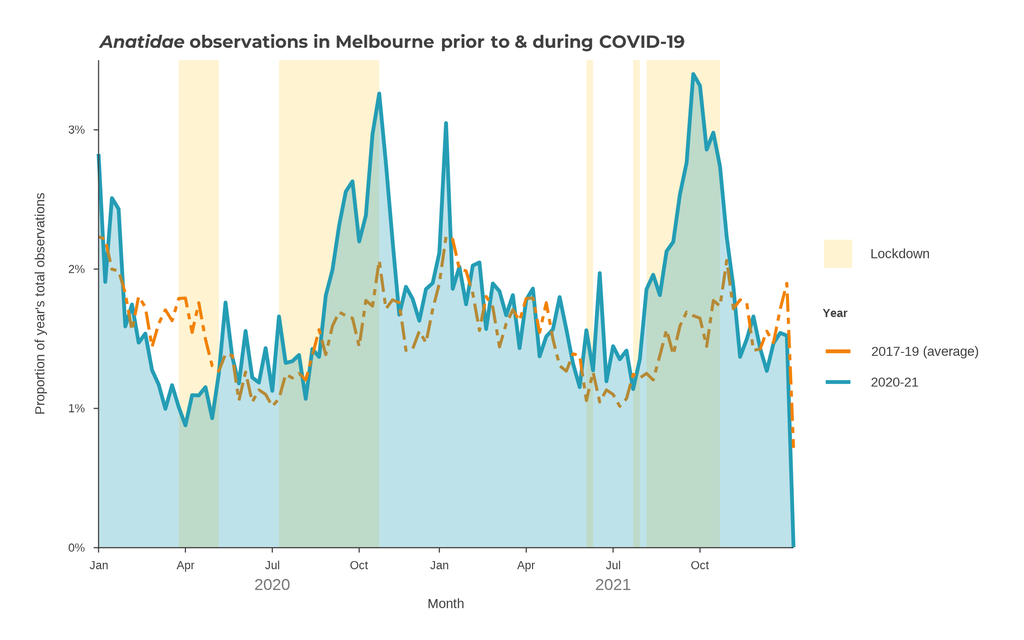

### Make a highlighted time-series plot

Time-series analyses can be handy for seeing trends over time, and exploring how trends relate to major events. Here, we show how to create an exploratory time-series plot comparing observations of waterbirds prior to and during the COVID-19 pandemic.

Apr 3, 2023

Thai Rushbrook, Olivia Torresan, Dax Kellie

14 min

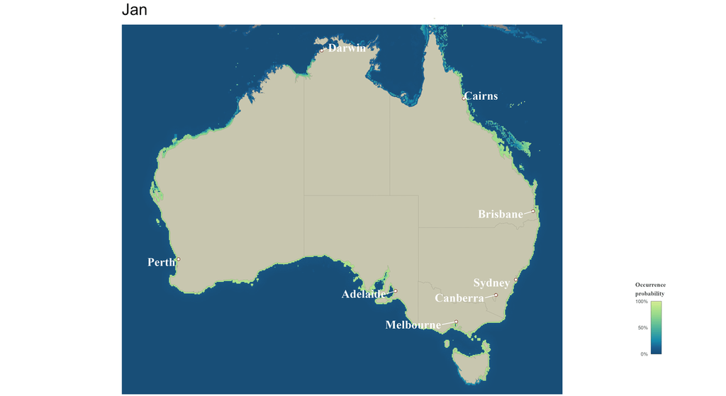

### Animated species distribution maps with {gifski}

One useful way to see changes in a species’ habitat range over time is by using animation to view multiple distributions in succession. Here we will model the distribution of *Nudibranchia* across Australia each month to create an animated GIF of its distribution over a year.

Mar 14, 2023

Stephanie Woolley, Olivia Torresan, Dax Kellie

20 min

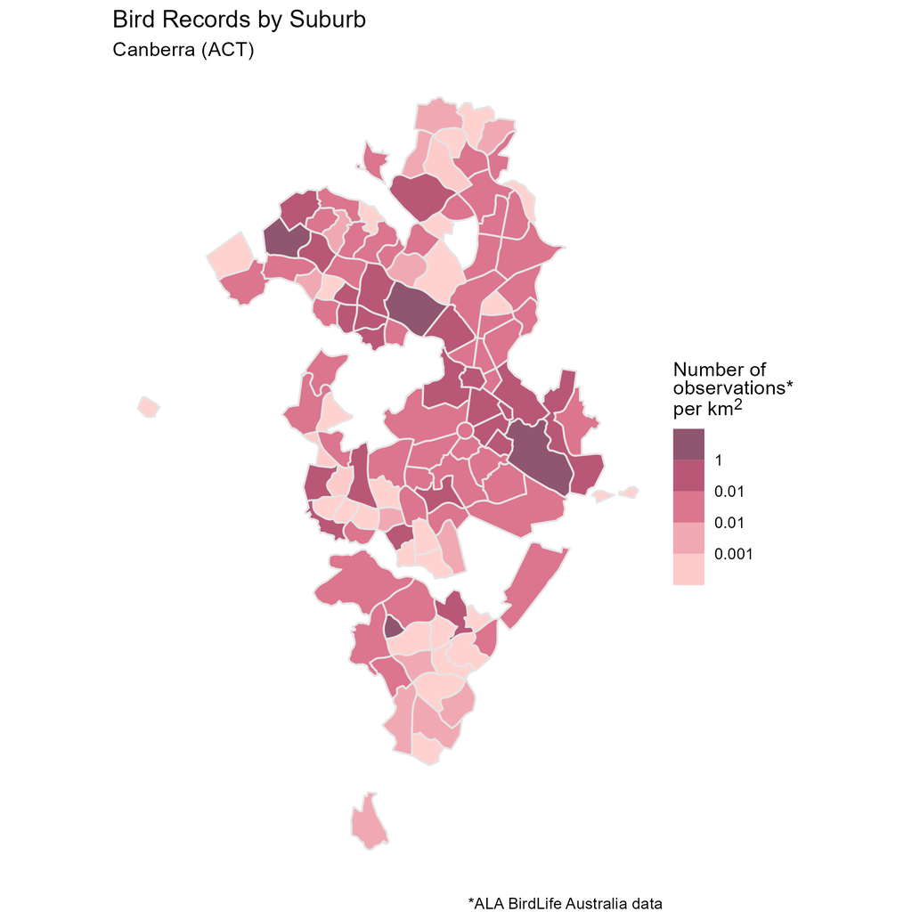

### Counting points in multipolygon shapefiles for choropleth mapping

Choropleth maps are an excellent way to visualise numbers of observations, but when using point data, calculating the number of points in each polygon can be difficult when using shapefiles. Here we demonstrate how to extract and summarise the number of points in each polygon to create a choropleth map.

Feb 6, 2023

Olivia Torresan, Dax Kellie

10 min

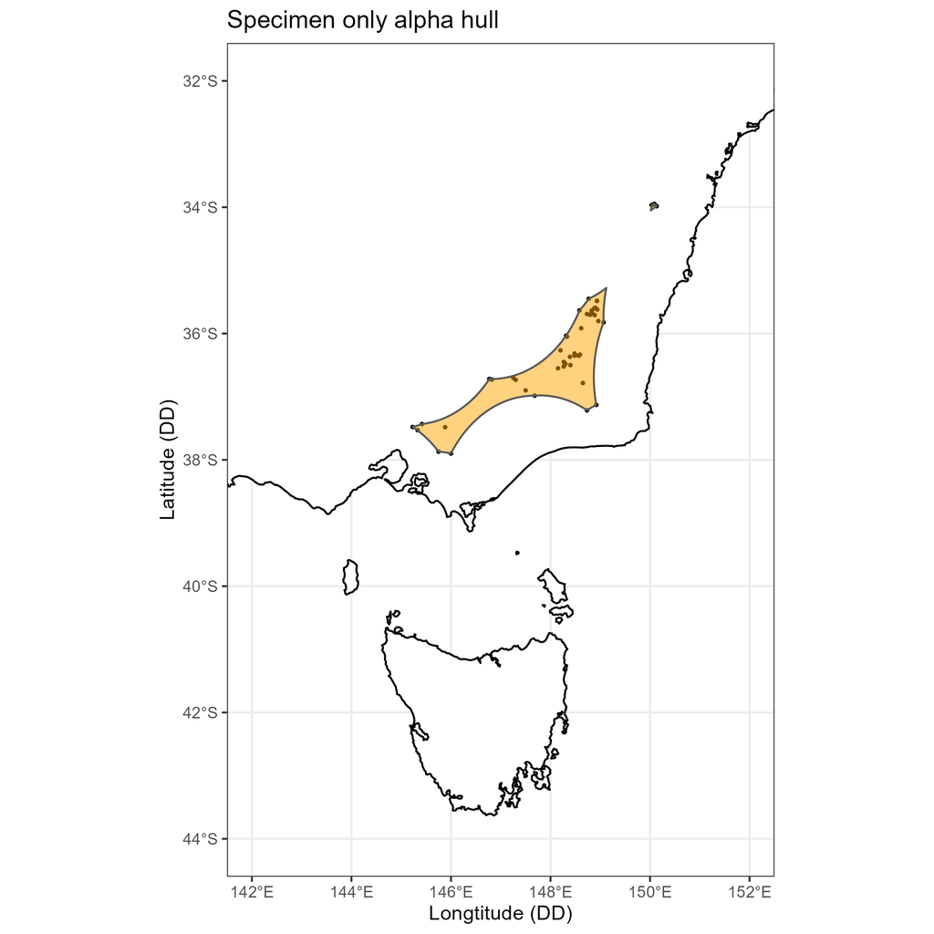

### Convex and alpha hulls for conservation mapping

Convex hulls and alpha hulls are wonderful alternatives for visualising species distributions when a species has very few existing observations. Here, we will show you how to create these spatial polygons using data from the ALA.

Oct 20, 2022

Margot Schneider, Fonti Kar

15 min

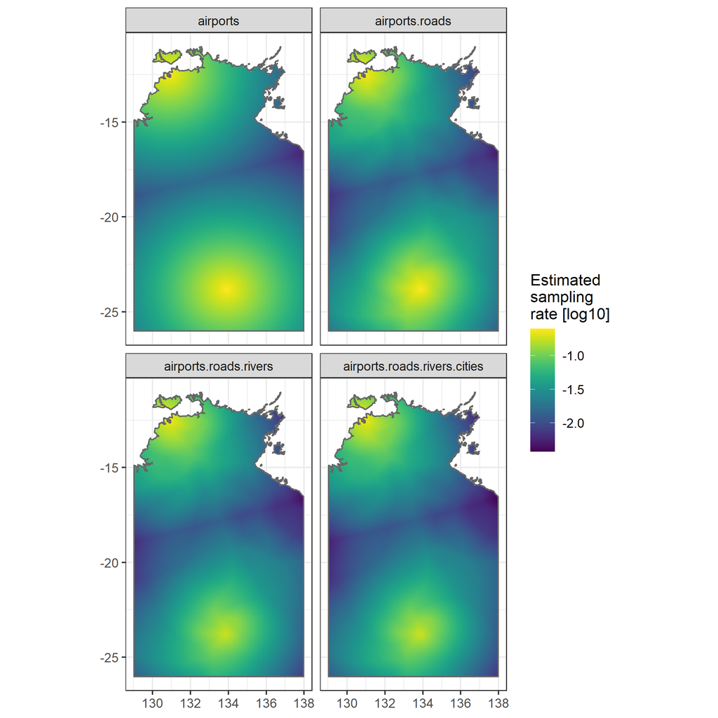

### Quantify geographic sampling bias with {sampbias}

Human biases play a large role in the data we collect about species. Here we show a simple method to quantify the bias of roads, cities, rivers and airports on species observations of legless lizards in the Northern Territory

Aug 8, 2022

Dax Kellie

11 min

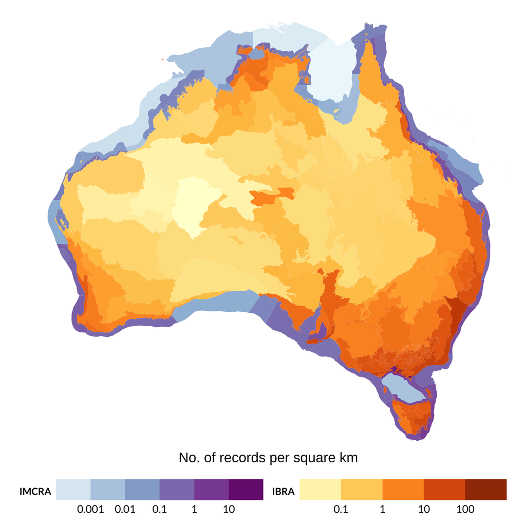

### Multiple colour scales in choropleth maps with {ggnewscale}

Using multiple colour scales can be a great way to visually differentiate between geographic categories on a map. Here, we demonstrate this by creating a choropleth map to represent the density of plant records from the ALA across bioregions in Australia, and add multiple colour scales to differentiate marine and terrestrial records

May 31, 2022

Shandiya Balasubramaniam

10 min

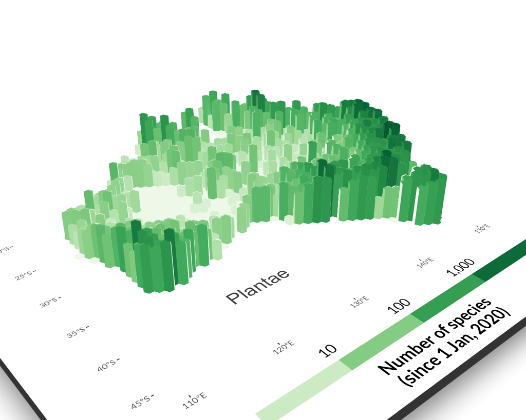

### Download plant species data by hexagon to make a 3D hex map

Making plots eye-catching can be useful for science communication. Here, we show how to make 3D plots in R with the `rayshader` package by visualising the number of species identified from ALA observations since 2020

May 23, 2022

Dax Kellie

12 min

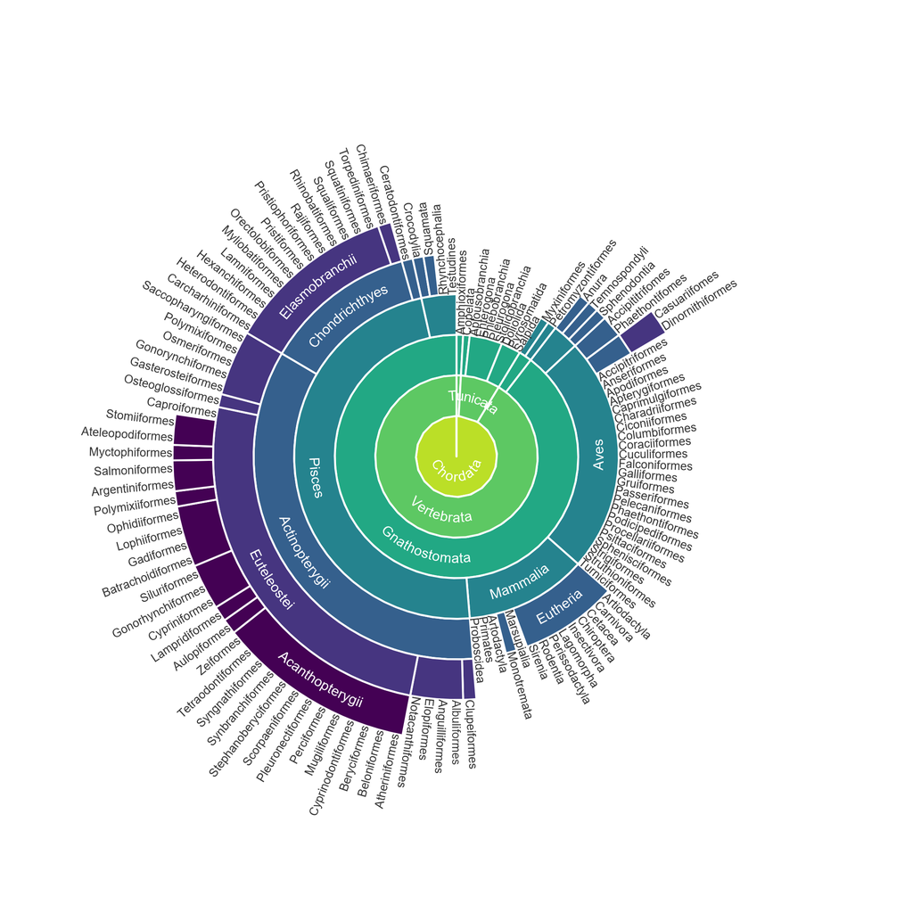

### Sunburst plots for taxonomic data

Since version 1.3.1 of {galah}, it has been possible to download taxonomic data using a ‘tree’ format from the {data.tree} package. Here I’ll demonstrate some ideas for plotting these trees using circular diagrams.

Feb 17, 2022

Martin Westgate

8 min

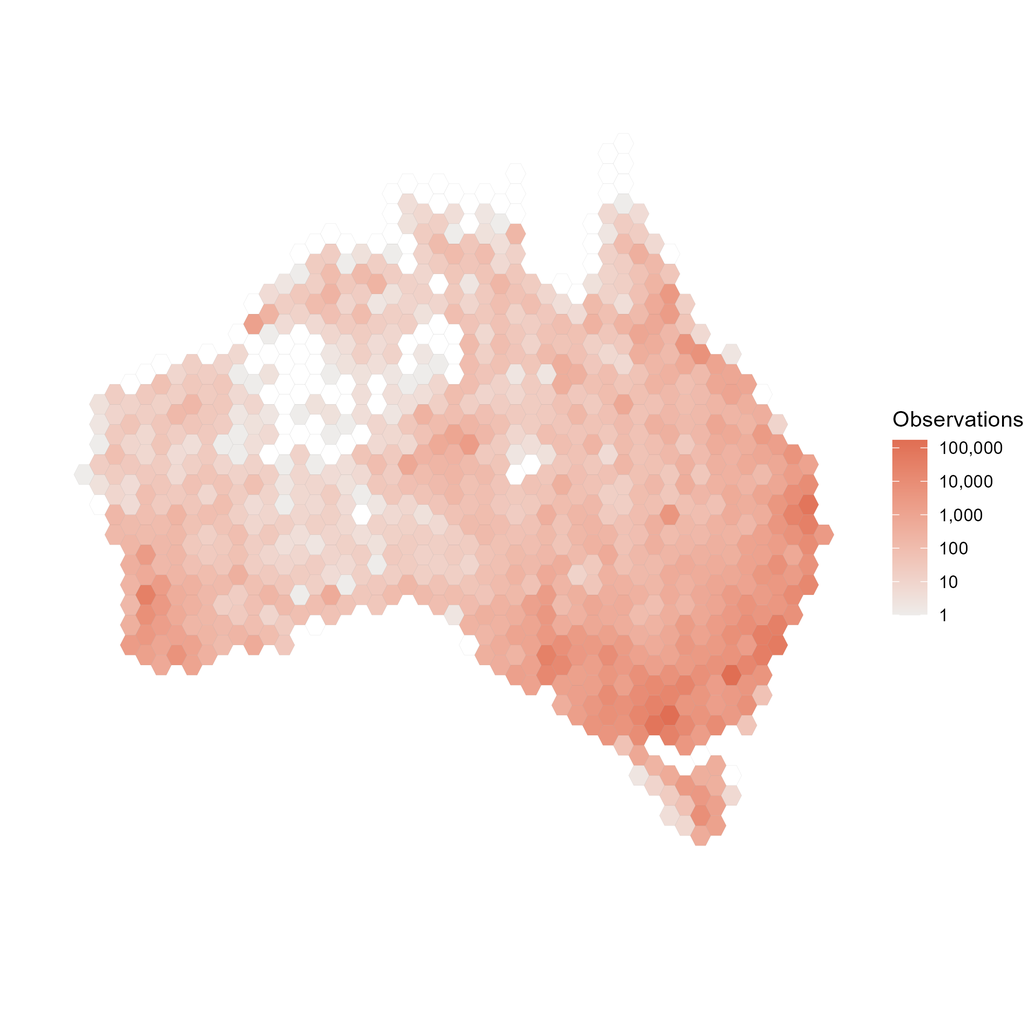

### Hex maps for species occurrence data

Hexagonal grid maps (i.e. hex maps) are one way to display information about the distribution of a species and the relative frequency that a species occurs in a given area. Here we will show how to make a hex map of magpie observations in Australia using `sf` and `ggplot2`.

Mar 1, 2021

Matilda Stevenson, Dax Kellie, Martin Westgate

8 min

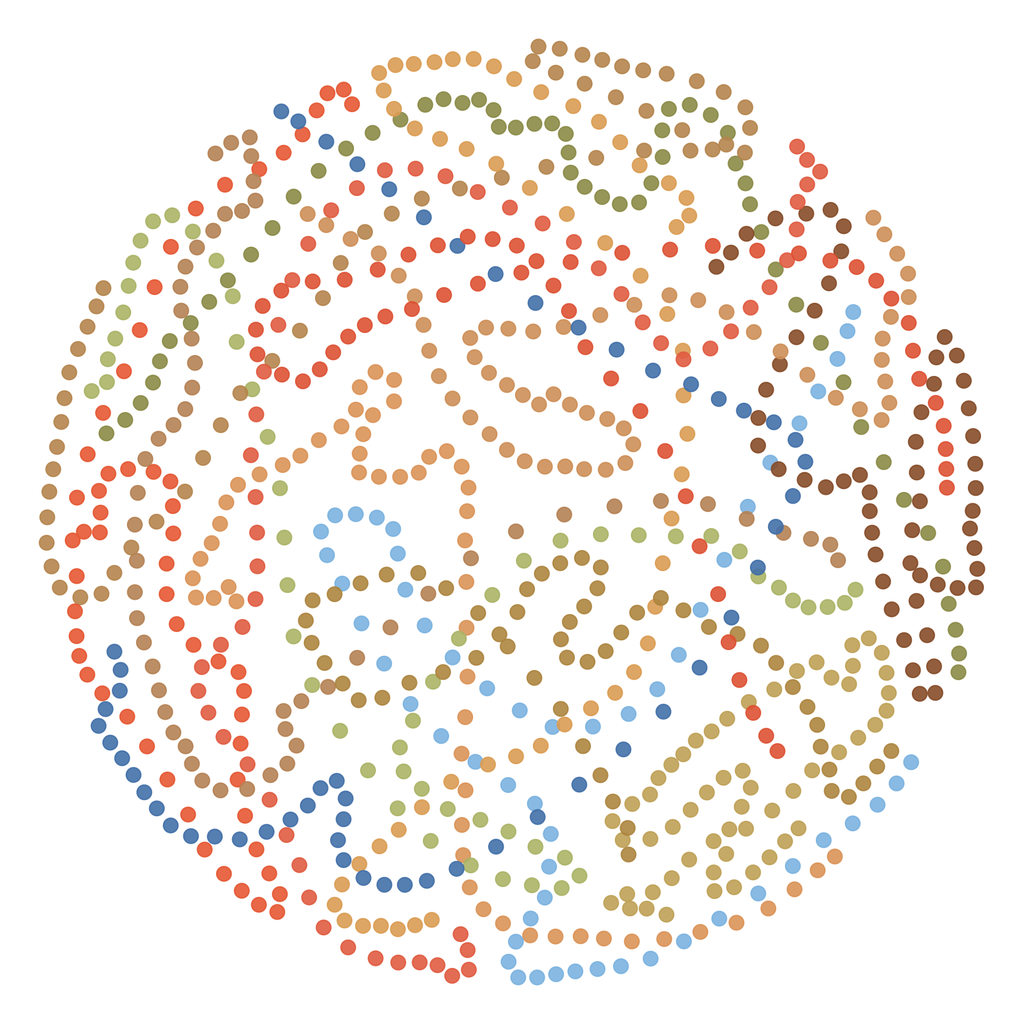

### Creating a color palette from an image

There are hundreds of color palettes in the R ecosystem, but sometimes we might want to use colors from a specific image. Here I show how to use the `paletter` package to create a color palette for the 2020 Eucalypt of the Year: the Western Australian Gimlet.

Jan 3, 2021

Martin Westgate

5 min

The ALA is made possible by contributions from its partners, is supported by [NCRIS](https://www.education.gov.au/national-collaborative-research-infrastructure-strategy-ncris), is hosted by [CSIRO](https://csiro.au/), and is the Australian node of [GBIF](https://www.gbif.org/en/).

**Acknowledgement of Traditional Owners and Country**

The Atlas of Living Australia acknowledges Australia's Traditional Owners and pays respect to the past and present Elders of the nation's Aboriginal and Torres Strait Islander communities. We honour and celebrate the spiritual, cultural and customary connections of Traditional Owners to country and the biodiversity that forms part of that country.

This work is licensed under a [Creative Commons Attribution 3.0 Australia License](https://creativecommons.org/licenses/by/3.0/au/)